# ML_Project_Assignment

IG

February 4, 2018

## Project Background and Objective

Using devices such as Jawbone Up, Nike FuelBand, and Fitbit it is now possible to collect a large amount of data about personal activity relatively inexpensively. These type of devices are part of the quantified self movement - a group of enthusiasts who take measurements about themselves regularly to improve their health, to find patterns in their behavior, or because they are tech geeks. One thing that people regularly do is quantify how much of a particular activity they do, but they rarely quantify how well they do it. The goal of this project is to use data from accelerometers on the belt, forearm, arm, and dumbell of 6 participants who were asked to perform barbell lifts correctly and incorrectly in 5 different ways to predict the manner in which they did the exercise.

The training data consisted of 19622 observations on some 150+ variables or features. The outcome variable to be predicted is called “classe” in the dataset that has 5 different values- codes as “A” through “E”. The test data consists of 20 cases that would be predicted using one of the ML predictors.

```r
#Load the raw data for the training sample
setwd("C:/Ishani/Learning R/Practical Machine Learning")
training_raw <- read.csv("./pml-training.csv")

columns <- data.frame(colnames(training_raw))
predictors <- training_raw[c(8:153)]
```

```r
library(caret)
library(dplyr)
nearZeroVar(predictors) # To identify variables with zero to low variations
```

```
##  [1]   5   6   7   8   9  10  13  16  19  44  45  46  47  48  49  50  51
## [18]  52  62  63  64  65  66  67  68  71  72  74  75  80  81  82  83  84
## [35]  85  88  91  94 118 119 120 121 122 123 124 126 127 129 130 132 135
## [52] 136 137 138 139 140 141 142 143
```

```r
#Eliminate variables that have low variability
predictors_v2 <- predictors[-c(5:10,13,16,19,44:52, 62:68,71,72,74,75,80:85, 91,94,118:124,126,127,129,130,132,135:143)]
#summary(predictors_v2)
#Calculate what proportion of the remaining variables has missing values
find_NA <- data.frame(colMeans(is.na(predictors_v2)))
find_NA <- rename(find_NA, proportion = colMeans.is.na.predictors_v2..)
find_NA <- tibble::rownames_to_column(find_NA,"variable")
find_NA2 <- filter(find_NA, proportion == 0)
#Select and Keep variables that have complete data
predictors_v3 <- subset(predictors_v2, select = c("roll_belt",

                                                  "pitch_belt",

                                                  "yaw_belt",

                                                  "total_accel_belt",

                                                  "gyros_belt_x",

                                                  "gyros_belt_y",

                                                  "gyros_belt_z",

                                                  "accel_belt_x",

                                                  "accel_belt_y",

                                                  "accel_belt_z",

                                                  "magnet_belt_x",

                                                  "magnet_belt_y",

                                                  "magnet_belt_z",

                                                  "roll_arm",

                                                  "pitch_arm",

                                                  "yaw_arm",

                                                  "total_accel_arm",

                                                  "gyros_arm_x",

                                                  "gyros_arm_y",

                                                  "gyros_arm_z",

                                                  "accel_arm_x",

                                                  "accel_arm_y",

                                                  "accel_arm_z",

                                                  "magnet_arm_x",

                                                  "magnet_arm_y",

                                                  "magnet_arm_z",

                                                  "roll_dumbbell",

                                                  "pitch_dumbbell",

                                                  "yaw_dumbbell",

                                                  "max_yaw_dumbbell",

                                                  "total_accel_dumbbell",

                                                  "gyros_dumbbell_x",

                                                  "gyros_dumbbell_y",

                                                  "gyros_dumbbell_z",

                                                  "accel_dumbbell_x",

                                                  "accel_dumbbell_y",

                                                  "accel_dumbbell_z",

                                                  "magnet_dumbbell_x",

                                                  "magnet_dumbbell_y",

                                                  "magnet_dumbbell_z",

                                                  "roll_forearm",

                                                  "pitch_forearm",

                                                  "yaw_forearm",

                                                  "total_accel_forearm",

                                                  "gyros_forearm_x",

                                                  "gyros_forearm_y",

                                                  "gyros_forearm_z"
                                                  ))
predictors_v3 <- cbind(predictors_v3, training_raw[160]) # Combining the outcome and the predictor variables together
```

```r
#Splitting the training datasets into two random samples in 70-30 ratio
set.seed(12345)
indexes = sample(1:nrow(predictors_v3), size=0.3*nrow(predictors_v3))
testing = predictors_v3[indexes,]
training = predictors_v3[-indexes,]

#Fitting a bagging algorithm on all variables
bag_fit_trial <- train(classe ~ ., method = "treebag", data = training)
varImp(bag_fit_trial)
```

```
## treebag variable importance
##
##   only 20 most important variables shown (out of 124)
##
##                   Overall
## roll_belt          100.00
## yaw_belt            89.37
## pitch_belt          83.34
## pitch_forearm       79.89
## roll_forearm        63.76
## magnet_dumbbell_y   61.77
## magnet_dumbbell_z   61.74
## accel_dumbbell_y    60.79
## roll_dumbbell       44.29
## accel_belt_z        38.57
## magnet_belt_y       36.21
## accel_dumbbell_z    33.53
## magnet_belt_z       33.40
## magnet_dumbbell_x   31.70
## yaw_arm             29.86
## gyros_belt_z        28.71
## accel_arm_x         26.34
## total_accel_belt    25.86
## magnet_belt_x       25.31
## yaw_dumbbell        24.96
```

```r
#Retaining only the top 20 variables as shown by variable importance chart

bag_fit <- train(classe ~ roll_belt +
                   yaw_belt +
                   pitch_belt +
                   pitch_forearm+
                   roll_forearm +
                   magnet_dumbbell_y+
                   magnet_dumbbell_z+
                   accel_dumbbell_y+
                   roll_dumbbell +
                   accel_belt_z +
                   magnet_belt_y+
                   accel_dumbbell_z+
                   magnet_belt_z+
                   magnet_dumbbell_x+
                   yaw_arm+
                   gyros_belt_z+
                   accel_arm_x+
                   total_accel_belt+
                   magnet_belt_x+
                   yaw_dumbbell, method = "treebag", data = training)

bagging_prediction <- data.frame(predict(bag_fit, newdata = testing[-48]))

bagging_prediction <- cbind(bagging_prediction, testing[48])
table(bagging_prediction)
```

```
##                                         classe
## predict.bag_fit..newdata...testing..48..    A    B    C    D    E
##                                        A 1643   22    2    0    1
##                                        B   11 1104    7    5    5
##                                        C    3   18  966    8    5
##                                        D    3   11   11  997    7
##                                        E    1    2    2    4 1048
```

```r
accuracy.bag <- (1644+1104+965+997+1048)/5886
```

# Prediction Accuracy from Bagging Algorithm on the testing sample is 0.9782535

```r
#Fitting the same model with random forest (Using the same set of variables)
library(randomForest)
```

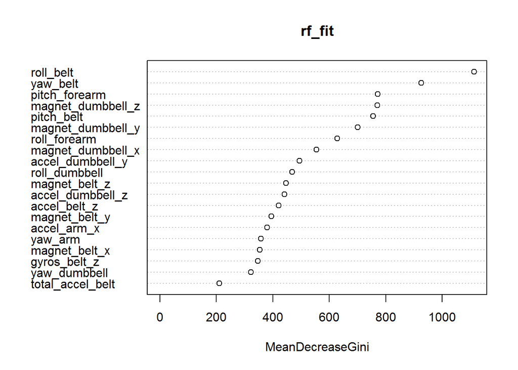

```r
rf_fit <- randomForest(classe ~ roll_belt +
                         yaw_belt +
                         pitch_belt +
                         pitch_forearm+
                         roll_forearm +
                         magnet_dumbbell_y+
                         magnet_dumbbell_z+
                         accel_dumbbell_y+
                         roll_dumbbell +
                         accel_belt_z +
                         magnet_belt_y+
                         accel_dumbbell_z+
                         magnet_belt_z+
                         magnet_dumbbell_x+
                         yaw_arm+
                         gyros_belt_z+
                         accel_arm_x+
                         total_accel_belt+
                         magnet_belt_x+
                         yaw_dumbbell,mtry = 3, ntree = 300, data = training)

varImpPlot(rf_fit,type=2)
```

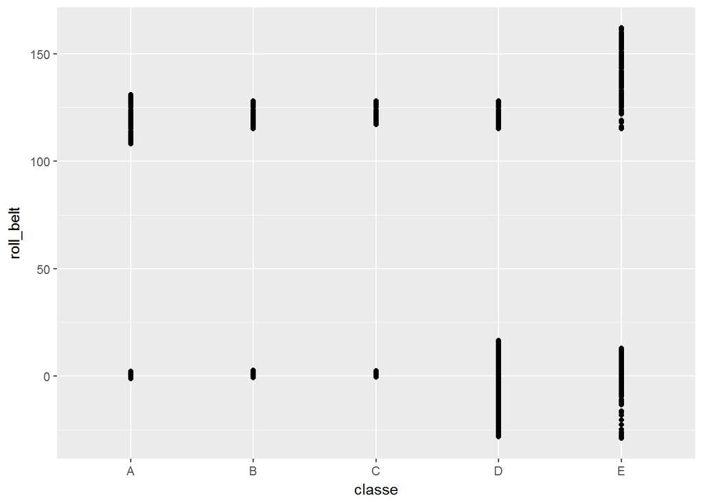

```r
#The graph indicates that roll_belt is the most important predictor

qplot(classe, roll_belt, data = training)
```

```r
rf_prediction <- data.frame(predict(rf_fit, newdata = testing[-48]))
rf_prediction <- cbind(rf_prediction, testing[48])
table(rf_prediction)
```

```
##                                        classe
## predict.rf_fit..newdata...testing..48..    A    B    C    D    E
##                                       A 1654    7    0    0    0
##                                       B    6 1133    5    0    0
##                                       C    0   12  981   12    1
##                                       D    0    5    2  999    6
##                                       E    1    0    0    3 1059
```

```r
accuracy.rf <- (1656+1134+978+1000+1059)/5886
```